# R package

Dan Groeneveld

2020-11-18

# Introduction

Congratulations for getting this far. To complete the evidence that you have made a working R package please answer the following by using the supplied rmd and upload the knitted html to CANVAS.

I will assume your package is called **MYPAC** and you have packaged and documented functions `myf1`, `myf2`, `myf3` and `myf4`.

Your actual package name and functions will obviously be called something else.

# myci

Please place your first function in the r chunk in the following way:

Once you are ready please remove the option `eval = FALSE`

```r
MATH4753GROE002::myci(d=c(1,2,3), n=3, a =0.05)
```

```
## [1] -0.4841377  4.4841377
```

# mycltdangroeneveld

Please place your second function in the r chunk in the following way:

Once you are ready please remove the option `eval = FALSE`

```r
 w =MATH4753GROE002::mycltdangroeneveld(n=10,iter=10000, a = 0, b= 5)
```

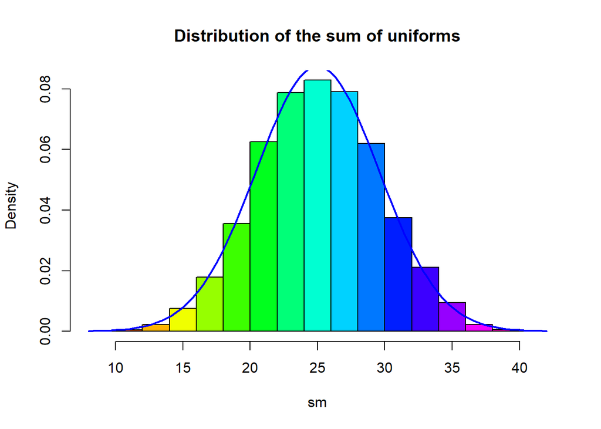

# myboot2dg

Please place your third function in the r chunk in the following way:

Once you are ready please remove the option `eval = FALSE`

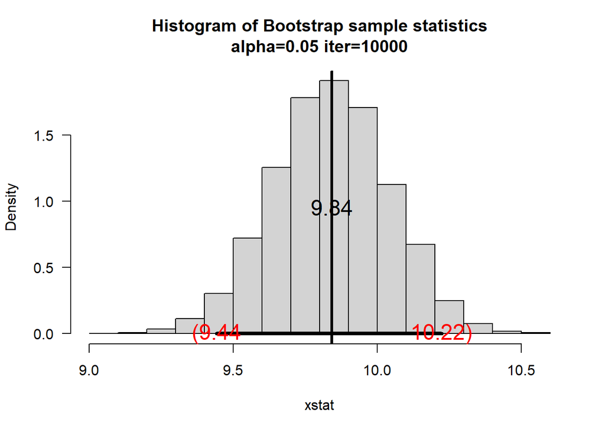

```r
sam = rnorm(100, mean = 10, sd =2)
MATH4753GROE002::myboot2dg(sam, iter = 10000, alpha = 0.05)
```

# dansample

Please place your forth function in the r chunk in the following way:

Once you are ready please remove the option `eval = FALSE`

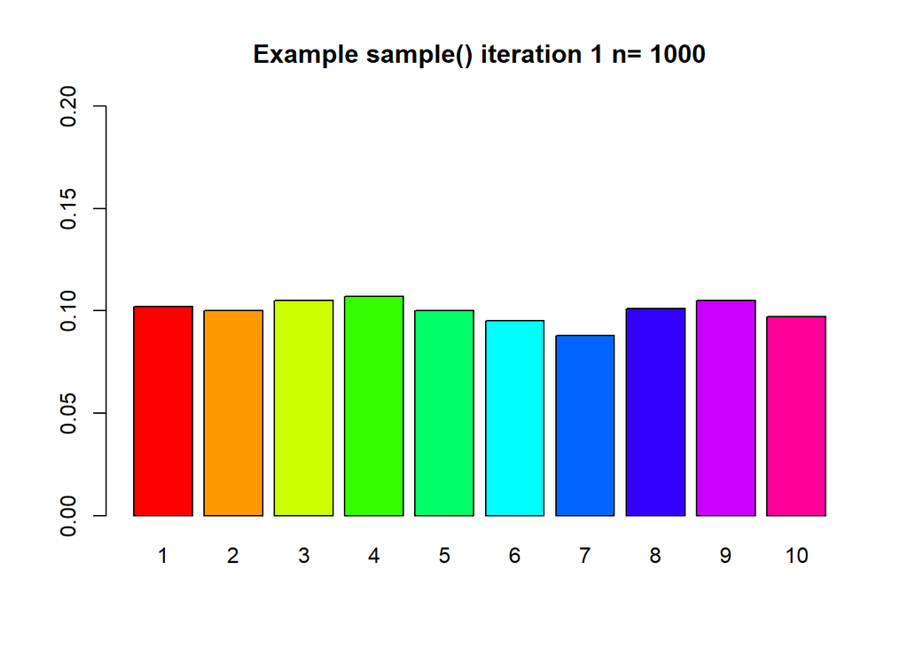

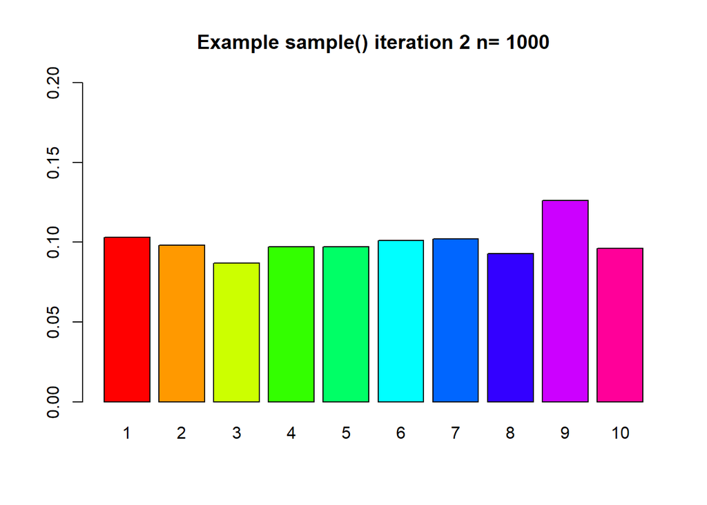

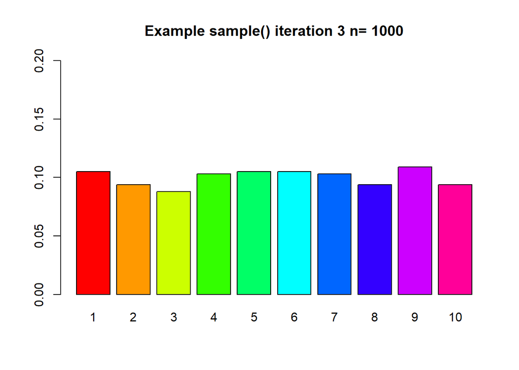

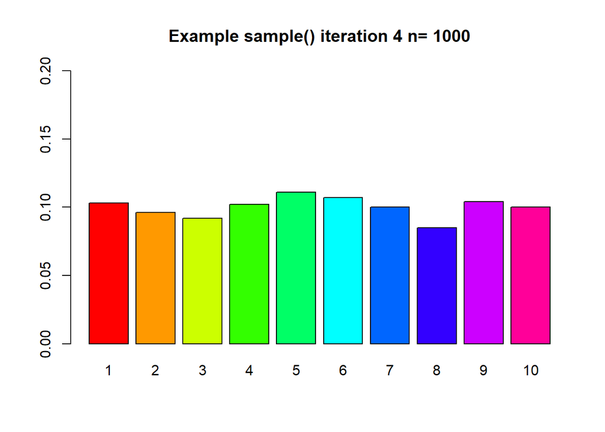

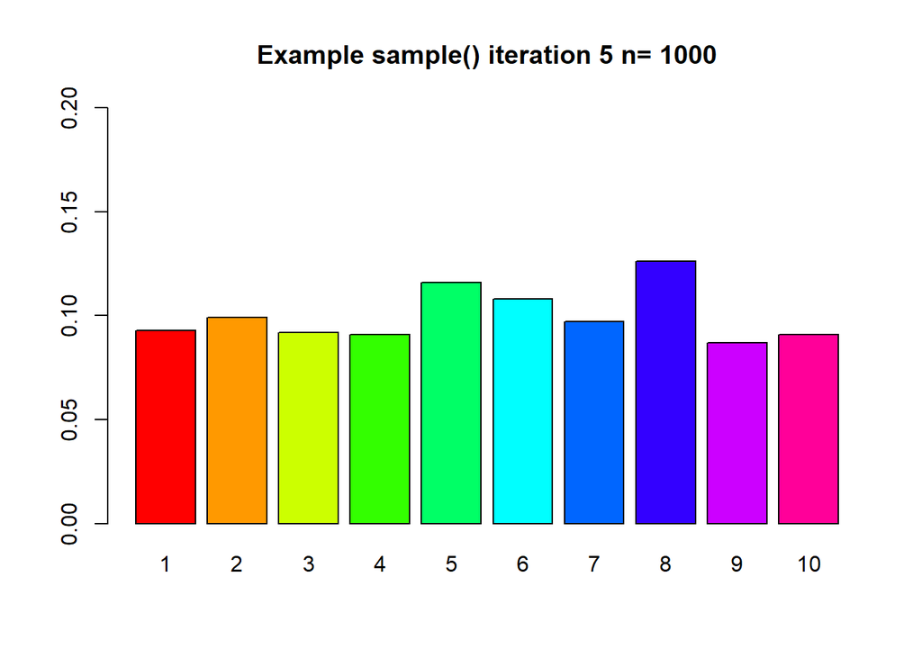

```r
MATH4753GROE002::dansample(n=1000, iter=5, time = 0.1)
```

# The github repository

This is the address of my GITHUB repository: https://github.com/dan-groeneveld/MATH4753GROE002